# 8 Weeks: Whole-Bacterium Assays & Effector Functions — Maternal TdaP vs TT

At the **infant baseline visit (8 weeks, before primary vaccination)** this part tests whether **maternal TdaP** shifts the infant’s whole-bacterium responses and antibody effector functions relative to **maternal TT** (referent). It covers two families:

- **Whole-bacterium assays** — SBA, WT_IgG, PTNA (serum bactericidal activity, whole-cell-binding IgG, and pertussis-toxin neutralization).
- **Effector functions** binding to individual antigens — **ADCD** (all six antigens PT, FHA, PRN, FIM, TT, DT), and **ADCP** / **ADNP** (PT, PRN, TT, DT only — no FHA or FIM assays).

Each feature is a **Wilcoxon rank-sum test of TdaP vs TT on log10 assay values — the same test used in the response-bubble grid.** Multiplicity is handled by **Benjamini–Hochberg within each assay class** (Whole / ADCD / ADCP / ADNP as separate families). The forest plot additionally carries the point estimate + interval that natively pair with that test: the **Hodges–Lehmann location shift and its Wilcoxon CI**, oriented **TdaP − TT**. With **TT as the reference level**, this is the effect of TdaP relative to TT, so a positive value means *higher with maternal TdaP*.

> **🧭 Maps to interpretation:** Infant-baseline (pre-primary-vaccination) read-out of the maternal vaccination effect on functional / whole-bacterium immunity, complementing the antigen×analyte bubble grid.
> - Q3 — Function vs binding: does the maternal effect reach functional read-outs (SBA/PTNA, ADCD/ADCP/ADNP), not just IgG binding?
> - Q2 — Antigen specificity: within each effector, is the effect concentrated in the vaccine antigens (PT/FHA/PRN) vs the toxoids (TT/DT)?

## Test Results (8 weeks)

**Subjects at 8 weeks:** TT n = 134, TdaP n = 131. **17 features tested** (3 whole-bacterium assays + 14 effector×antigen cells); BH within each assay class.

8-week maternal TdaP-vs-TT differences (TT referent). Median = median log10 assay value per arm; HL shift = Hodges–Lehmann location shift (TdaP−TT, log10) with Wilcoxon CI; Fold = 10^(HL) = TdaP/TT ratio on the linear scale; Direction uses the bubble convention; p = Wilcoxon rank-sum (same test as the bubbles); p (BH) = Benjamini–Hochberg within the assay class.

| Class | Assay | Antigen | n TT | n TdaP | Median TT | Median TdaP | HL shift (TdaP−TT) | 95% CI | Fold (TdaP/TT) | Direction | p | p (BH) |  |
| --- | --- | --- | --- | --- | --- | --- | --- | --- | --- | --- | --- | --- | --- |
| Whole bacterium assays | SBA | — | 117 | 105 | 0.602 | 1.959 | 1.145 | [0.86, 1.37] | 13.97 | Higher TdaP | 0.00e+00 | 0.00e+00 | *** |
| Whole bacterium assays | WT IgG | — | 109 | 114 | -0.170 | 0.381 | 0.532 | [0.38, 0.68] | 3.40 | Higher TdaP | 0.00e+00 | 0.00e+00 | *** |
| Whole bacterium assays | PTNA | — | 121 | 116 | 1.505 | 2.107 | 0.602 | [0.60, 0.90] | 4.00 | Higher TdaP | 0.00e+00 | 0.00e+00 | *** |
| ADCD | ADCD | PT | 134 | 128 | 2.354 | 3.111 | 0.730 | [0.63, 0.82] | 5.37 | Higher TdaP | 0.00e+00 | 0.00e+00 | *** |
| ADCD | ADCD | FHA | 134 | 128 | 2.423 | 3.109 | 0.674 | [0.59, 0.75] | 4.72 | Higher TdaP | 0.00e+00 | 0.00e+00 | *** |
| ADCD | ADCD | PRN | 134 | 128 | 2.485 | 2.996 | 0.505 | [0.42, 0.59] | 3.20 | Higher TdaP | 0.00e+00 | 0.00e+00 | *** |
| ADCD | ADCD | FIM | 134 | 128 | 1.550 | 1.623 | 0.077 | [0.03, 0.13] | 1.19 | Higher TdaP | 1.74e-03 | 2.09e-03 | ** |
| ADCD | ADCD | TT | 134 | 128 | 3.126 | 3.147 | 0.000 | [-0.04, 0.04] | 1.00 | Higher TdaP | 9.82e-01 | 9.82e-01 | ns |
| ADCD | ADCD | DT | 134 | 128 | 3.036 | 3.206 | 0.221 | [0.13, 0.32] | 1.67 | Higher TdaP | 1.80e-06 | 2.70e-06 | *** |
| ADCP | ADCP | PT | 127 | 126 | 0.778 | 1.000 | 0.211 | [0.18, 0.27] | 1.63 | Higher TdaP | 0.00e+00 | 0.00e+00 | *** |
| ADCP | ADCP | PRN | 127 | 126 | 1.362 | 1.398 | 0.053 | [0.02, 0.09] | 1.13 | Higher TdaP | 1.24e-03 | 2.47e-03 | ** |
| ADCP | ADCP | TT | 127 | 126 | 1.663 | 1.602 | -0.054 | [-0.11, -0.00] | 0.88 | Lower TdaP | 4.68e-02 | 6.24e-02 | ns |
| ADCP | ADCP | DT | 127 | 126 | 1.000 | 1.000 | 0.000 | [-0.00, 0.03] | 1.00 | No effect | 6.72e-01 | 6.72e-01 | ns |
| ADNP | ADNP | PT | 127 | 126 | 1.000 | 1.041 | 0.041 | [-0.00, 0.08] | 1.10 | Higher TdaP | 7.59e-02 | 1.52e-01 | ns |
| ADNP | ADNP | PRN | 127 | 126 | 1.477 | 1.585 | 0.118 | [0.06, 0.18] | 1.31 | Higher TdaP | 5.98e-05 | 2.39e-04 | *** |
| ADNP | ADNP | TT | 127 | 126 | 1.146 | 1.114 | 0.000 | [-0.07, 0.07] | 1.00 | Lower TdaP | 9.73e-01 | 9.73e-01 | ns |
| ADNP | ADNP | DT | 127 | 126 | 0.903 | 0.954 | 0.000 | [-0.00, 0.05] | 1.00 | Higher TdaP | 5.67e-01 | 7.56e-01 | ns |

## Forest Plot (8 weeks)

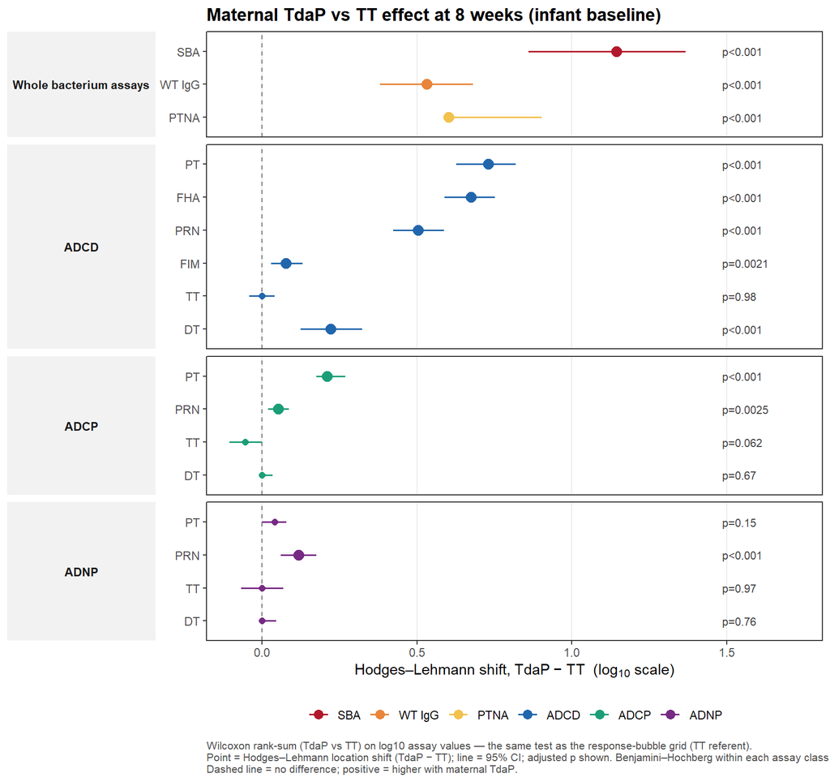

Maternal TdaP-vs-TT effect at 8 weeks for whole-bacterium assays (SBA, WT IgG, PTNA) and antibody effector functions (ADCD, ADCP, ADNP). Point = Hodges–Lehmann shift (TdaP−TT, log10); line = 95% CI; dashed line = no difference; positive = higher with maternal TdaP. BH-adjusted p at right; larger dot = BH p < 0.05. Colour differentiates each whole-bacterium assay and each effector function.

## Notes on Method Choices

- **Same test as the bubbles.** The p-values above come from `wilcox.test()` on log10 assay values, TT vs TdaP, exactly as in `bubble_arm_effect()`. Only the effect *display* differs: the bubbles show a bare difference of medians (no interval), whereas a forest plot needs one, so the point/CI use the Hodges–Lehmann shift and Wilcoxon `conf.int` — the estimator/interval that belongs to this test. The raw `p` is identical to the bubble p.
- **Orientation.** Everything is oriented **TdaP − TT** with **TT as the reference level**, so the estimate is the effect of TdaP relative to TT (positive = higher with maternal TdaP), the sign convention of Saso et al. 2026 Figure 2C/D. The `Direction` column reuses the bubble labels (“Higher TdaP” / “Lower TdaP”). Magnitudes and p-values are identical to the bubble grid; only the displayed sign convention differs (the bubble reports median(TT) − median(TdaP)).
- **Multiplicity.** Benjamini–Hochberg is applied **within each assay class** (Whole = 3, ADCD = 6, ADCP = 4, ADNP = 4 tests), so each functional family is corrected on its own. To correct across the whole panel instead, call `infmon2_arm_effect(..., by_class = FALSE)`; to change method, set `p_adjust_method`.
- **Antigen coverage.** ADCP and ADNP have no FHA or FIM assays, so those cells are absent by design (not missing data). ADCD spans all six antigens.
- **Infant arms pooled.** This is the overall maternal effect at baseline. For an aP/wP-stratified version, pass `infant_arm_sel = "aP"` / `"wP"` to `infmon2_arm_effect()`.